# Regression Models - Week 4

Saul Lugo

January 2, 2016

# Logistic Regression (Binary Data) Example

The dataset is a collection of games outcomes for the Baltimore Ravens. The idea of the model is to predict whether of not the Ravens win given their score in the game.

```r
download.file("https://dl.dropboxusercontent.com/u/7710864/data/ravensData.rda"
              , destfile="./data/ravensData.rda",method="curl")
load("./data/ravensData.rda")
head(ravensData)
```

```
##   ravenWinNum ravenWin ravenScore opponentScore
## 1           1        W         24             9
## 2           1        W         38            35
## 3           1        W         28            13
## 4           1        W         34            31
## 5           1        W         44            13
## 6           0        L         23            24
```

As the outcome is binary, fitting a linear model would result in a poor model for predicion:

```r
y <- ravensData$ravenWinNum
n <- length(y)
x <- ravensData$ravenScore
fit <- lm(y ~ x)
summary(fit)
```

```
##
## Call:
## lm(formula = y ~ x)
##
## Residuals:
##     Min      1Q  Median      3Q     Max
## -0.7302 -0.5076  0.1824  0.3215  0.5719
##
## Coefficients:
##             Estimate Std. Error t value Pr(>|t|)
## (Intercept) 0.285032   0.256643   1.111   0.2814
## x           0.015899   0.009059   1.755   0.0963 .
## ---
## Signif. codes:  0 '***' 0.001 '**' 0.01 '*' 0.05 '.' 0.1 ' ' 1
##
## Residual standard error: 0.4464 on 18 degrees of freedom
## Multiple R-squared:  0.1461, Adjusted R-squared:  0.09868
## F-statistic:  3.08 on 1 and 18 DF,  p-value: 0.09625
```

```r
co <- summary(fit)$coefficients
co
```

```
##               Estimate  Std. Error  t value   Pr(>|t|)
## (Intercept) 0.28503172 0.256643165 1.110615 0.28135043
## x           0.01589917 0.009058997 1.755069 0.09625261
```

```r
bo <- co[1,1]
b1 <- co[2,1]
yhat <- bo + b1 * x
result_comparison <- cbind(y,yhat,y-yhat)
result_comparison
```

```
##       y      yhat
##  [1,] 1 0.6666117  0.33338825
##  [2,] 1 0.8892001  0.11079990
##  [3,] 1 0.7302084  0.26979158
##  [4,] 1 0.8256034  0.17439657
##  [5,] 1 0.9845951  0.01540489
##  [6,] 0 0.6507126 -0.65071258
##  [7,] 1 0.7779059  0.22209408
##  [8,] 1 0.6507126  0.34928742
##  [9,] 1 0.4281242  0.57187577
## [10,] 1 0.7779059  0.22209408
## [11,] 0 0.4917209 -0.49172090
## [12,] 1 0.6825109  0.31748908
## [13,] 1 1.1594860 -0.15948595
## [14,] 1 0.4917209  0.50827910
## [15,] 1 0.5394184  0.46058160
## [16,] 0 0.6030151 -0.60301508
## [17,] 0 0.7302084 -0.73020842
## [18,] 0 0.5553176 -0.55531757
## [19,] 1 0.8097043  0.19029574
## [20,] 0 0.5553176 -0.55531757
```

As a linear model would be a poor model in this case, we use a Generalized Linear Model with a **Logistic Regression Model** which is more appropriate for binary or binomial outcomes:

```r
require(ggplot2)
logRegRavens <- glm(y ~ x, family = "binomial") #the family parameter specify the distribution of the outcome
summary(logRegRavens)
```

```
##
## Call:
## glm(formula = y ~ x, family = "binomial")
##
## Deviance Residuals:
##     Min       1Q   Median       3Q      Max
## -1.7575  -1.0999   0.5305   0.8060   1.4947
##
## Coefficients:
##             Estimate Std. Error z value Pr(>|z|)
## (Intercept) -1.68001    1.55412  -1.081     0.28
## x            0.10658    0.06674   1.597     0.11
##
## (Dispersion parameter for binomial family taken to be 1)
##
##     Null deviance: 24.435  on 19  degrees of freedom
## Residual deviance: 20.895  on 18  degrees of freedom
## AIC: 24.895
##
## Number of Fisher Scoring iterations: 5
```

```r
newco <- summary(logRegRavens)$coefficients
newco
```

```
##               Estimate Std. Error   z value  Pr(>|z|)
## (Intercept) -1.6800087 1.55411571 -1.081006 0.2796944
## x            0.1065822 0.06673754  1.597035 0.1102578
```

```r
nbo <- newco[1,1]
nb1 <- newco[2,1]
newYhat <- exp(nbo + nb1*x)/(1 + exp(nbo + nb1*x))
newYhat
```

```
##  [1] 0.7064002 0.9145199 0.7865566 0.8747675 0.9530063 0.6838198 0.8353515
##  [8] 0.6838198 0.3272237 0.8353515 0.4269172 0.7280094 0.9849618 0.4269172
## [15] 0.5063263 0.6110280 0.7865566 0.5329245 0.8626177 0.5329245
```

```r
result_comparison <- cbind(newYhat,result_comparison)
result_comparison
```

```
##         newYhat y      yhat
##  [1,] 0.7064002 1 0.6666117  0.33338825
##  [2,] 0.9145199 1 0.8892001  0.11079990
##  [3,] 0.7865566 1 0.7302084  0.26979158
##  [4,] 0.8747675 1 0.8256034  0.17439657
##  [5,] 0.9530063 1 0.9845951  0.01540489
##  [6,] 0.6838198 0 0.6507126 -0.65071258
##  [7,] 0.8353515 1 0.7779059  0.22209408
##  [8,] 0.6838198 1 0.6507126  0.34928742
##  [9,] 0.3272237 1 0.4281242  0.57187577
## [10,] 0.8353515 1 0.7779059  0.22209408
## [11,] 0.4269172 0 0.4917209 -0.49172090
## [12,] 0.7280094 1 0.6825109  0.31748908
## [13,] 0.9849618 1 1.1594860 -0.15948595
## [14,] 0.4269172 1 0.4917209  0.50827910
## [15,] 0.5063263 1 0.5394184  0.46058160
## [16,] 0.6110280 0 0.6030151 -0.60301508
## [17,] 0.7865566 0 0.7302084 -0.73020842
## [18,] 0.5329245 0 0.5553176 -0.55531757
## [19,] 0.8626177 1 0.8097043  0.19029574
## [20,] 0.5329245 0 0.5553176 -0.55531757
```

```r
logRegRavens$fitted
```

```
##         1         2         3         4         5         6         7
## 0.7064002 0.9145199 0.7865566 0.8747675 0.9530063 0.6838198 0.8353515
##         8         9        10        11        12        13        14
## 0.6838198 0.3272237 0.8353515 0.4269172 0.7280094 0.9849618 0.4269172
##        15        16        17        18        19        20
## 0.5063263 0.6110280 0.7865566 0.5329245 0.8626177 0.5329245
```

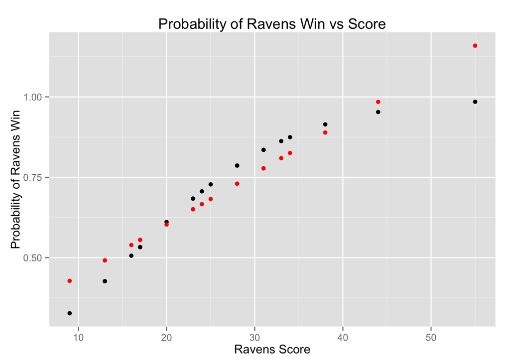

```r
result_comparison <- data.frame(result_comparison)
result_comparison <- cbind(result_comparison,x)
result_comparison <- data.frame(result_comparison)
g <- ggplot(aes(x=x, y=newYhat), data=result_comparison)
g <- g + geom_point()
g <- g + geom_point(aes(x=x, y=yhat), data=result_comparison, col = "red")
g <- g + xlab("Ravens Score") + ylab("Probability of Ravens Win") + ggtitle("Probability of Ravens Win vs Score")
g
```

# Coefficients Interpretation

```r
exp(logRegRavens$coefficient)
```

```
## (Intercept)           x
##   0.1863724   1.1124694
```

```r
exp(confint(logRegRavens))
```

```
##                   2.5 %   97.5 %
## (Intercept) 0.005674966 3.106384
## x           0.996229662 1.303304
```

However, the confidence interval for B1 coefficient includes 1. That means that the coefficient is not statistically significant.

# Poisson GLM

Example with web traffic:

```r
download.file("https://dl.dropboxusercontent.com/u/7710864/data/gaData.rda",destfile="./data/gaData.rda",method="curl")
load("./data/gaData.rda")
gaData$julian <- julian(gaData$date)
head(gaData)
```

```
##         date visits simplystats julian
## 1 2011-01-01      0           0  14975
## 2 2011-01-02      0           0  14976
## 3 2011-01-03      0           0  14977
## 4 2011-01-04      0           0  14978
## 5 2011-01-05      0           0  14979
## 6 2011-01-06      0           0  14980
```

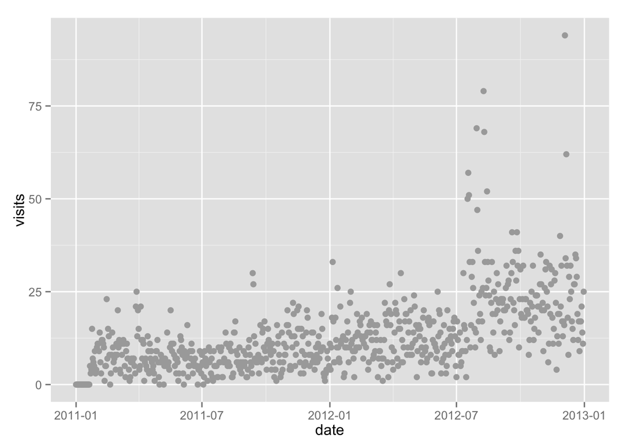

```r
g2 <- ggplot(aes(x = date, y = visits), data=gaData)
g2 <- g2 + geom_point(pch=19, col="darkgrey", xlab="Date", ylab="Visits")
g2
```

Let’s fit a linear regresion line:

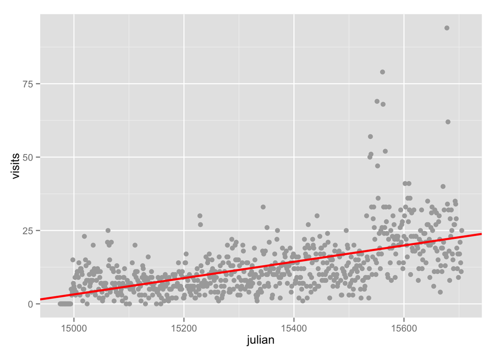

```r
lm1 <- lm(gaData$visits ~ gaData$julian)
g2 <- ggplot(aes(x = julian, y = visits), data=gaData)
g2 <- g2 + geom_point(pch=19, col="darkgrey", xlab="Julian Date", ylab="Visits")
co1 <- summary(lm1)$coefficients
g2 <- g2 + geom_abline(intercept = co1[1,1], slope = co1[2,1], col="red",lwd=1)
g2
```

So, we can see that a linear model is not a good fit for this count data.

Then, let’s take the log of the outcome and fit a linear model with it:

```r
#here the + 1 term is to avoid taking the log of zero
lm2 <- lm(I(log(gaData$visits + 1)) ~ gaData$julian)
lm2
```

```
##
## Call:
## lm(formula = I(log(gaData$visits + 1)) ~ gaData$julian)
##
## Coefficients:
##   (Intercept)  gaData$julian
##    -33.043544       0.002307
```

```r
round(exp(lm2$coefficients),3)
```

```
##   (Intercept) gaData$julian
##         0.000         1.002
```

Now, let’s fit a model with a **Poisson Regression**

```r
glm1 <- glm(gaData$visits ~ gaData$julian, family = "poisson")
glm1
```

```
##
## Call:  glm(formula = gaData$visits ~ gaData$julian, family = "poisson")
##
## Coefficients:
##   (Intercept)  gaData$julian
##    -32.749836       0.002293
##
## Degrees of Freedom: 730 Total (i.e. Null);  729 Residual
## Null Deviance:       5150
## Residual Deviance: 3122  AIC: 6070
```

```r
co2 <- summary(glm1)$coefficients
co2
```

```
##                    Estimate   Std. Error  z value Pr(>|z|)
## (Intercept)   -32.749835924 8.129718e-01 -40.2841        0
## gaData$julian   0.002293051 5.265741e-05  43.5466        0
```

```r
exp(co2)
```

```
##                   Estimate Std. Error      z value Pr(>|z|)
## (Intercept)   5.983110e-15   2.254598 3.197704e-18        1
## gaData$julian 1.002296e+00   1.000053 8.166751e+18        1
```

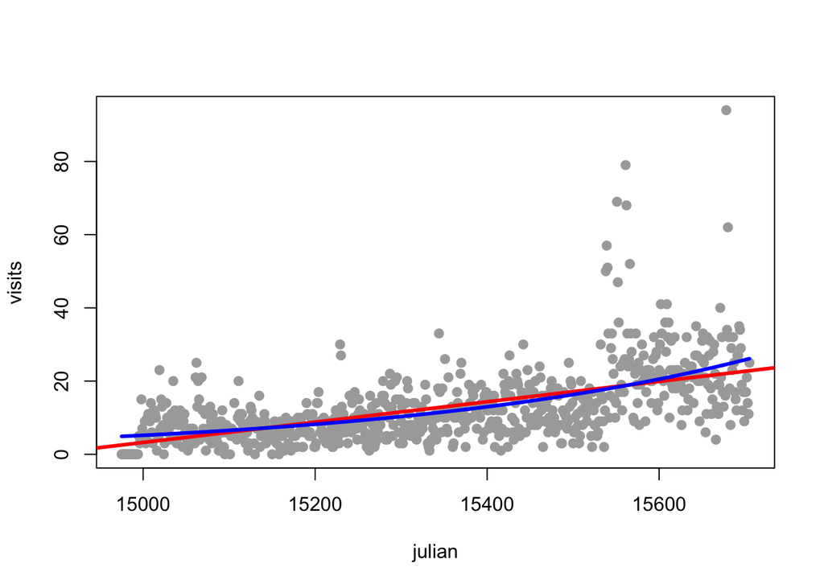

```r
plot(gaData$julian, gaData$visits, pch=19, col="darkgrey", xlab="julian", ylab = "visits")
abline(lm1, col = "red", lwd = "3")
lines(gaData$julian, glm1$fitted, col = "blue", lwd = "3")
```

We can see that the blue line that represents the GLM Poisson Regression model fits better the data.